# Personal activity monitoring device data

It is now possible to collect a large amount of data about personal movement using activity monitoring devices such as a Fitbit, Nike Fuelband, or Jawbone Up. These type of devices are part of the “quantified self” movement – a group of enthusiasts who take measurements about themselves regularly to improve their health, to find patterns in their behavior, or because they are tech geeks.

This assignment makes use of data from such a personal activity monitoring device. This device collects data at 5 minute intervals through out the day. The data consists of two months of data from an anonymous individual collected during the months of October and November, 2012 and include the number of steps taken in 5 minute intervals each day.

```
Dataset: Activity monitoring data [52K]
Variables:
  steps: Number of steps taking in a 5-minute interval (missing values are coded as NA)
  date: The date on which the measurement was taken in YYYY-MM-DD format
  interval: Identifier for the 5-minute interval in which measurement was taken
Total observations:17,568
```

Data Analysis

1. Loading and preprocessing the data

This chunk of code loads the data and does initial pre-processing on it to remove the N/A values and and converting date into a factor variable.

```r
library(ggplot2)
library(dplyr)
library(reshape2)
if(!file.exists("./data")){dir.create("./data")}
unzip(zipfile="./repdata_data_activity.zip",exdir="./data")
files<-list.files("./data", recursive=TRUE)
datafile<- read.csv("./data/activity.csv")
datafile<- datafile [!is.na(datafile$steps), ]
datafile[ ,2] <- factor(as.character(datafile[ ,2]))
```

2. Relationship of average number of steps taken and day of measurement

This chunk of code looks at the total steps by date, and reports the Mean and Median of the total number of steps as a function of date.

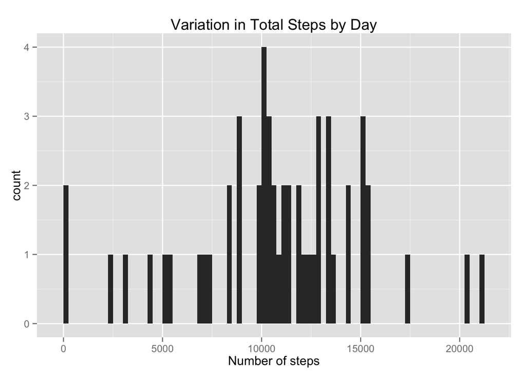

```r
dataByDay<- aggregate(steps ~ date, data=datafile, FUN=sum)
ggplot(dataByDay, aes(x=steps))+geom_histogram(binwidth=250)+ggtitle("Variation in Total Steps by Day")+ xlab("Number of steps")
```

```r
print(paste0(round(mean(dataByDay$steps),2)," is the mean number of total daily steps across all days of measurements."))
```

```
## [1] "10766.19 is the mean number of total daily steps across all days of measurements."
```

```r
print(paste0(round(median(dataByDay$steps),2)," is the median of total daily steps across all days of measurements."))
```

```
## [1] "10765 is the median of total daily steps across all days of measurements."
```

3. Variation in average steps by 5-minute intervals

This chunk of code looks at the average number of steps by the intervals averaged across all days, and determines which 5 minute interval across all days has the maximum number of steps.

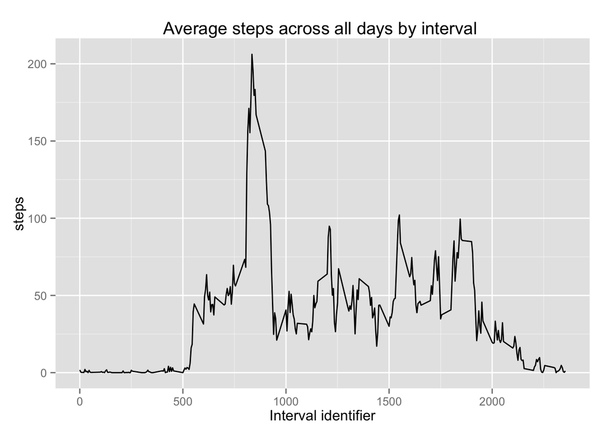

```r
dataByInterval<- aggregate(steps ~ interval, data=datafile, FUN=mean)
ggplot(dataByInterval, aes(x=interval, y=steps))+geom_line()+ggtitle("Average steps across all days by interval ")+xlab("Interval identifier")
```

```r
HighestStepsInt<- dataByInterval[dataByInterval$steps==max(dataByInterval$steps), ]$interval
HighestSteps<- dataByInterval[dataByInterval$steps==max(dataByInterval$steps), ]$steps
print(paste0("The maximum average number of steps are ", round(HighestSteps,2), " and these are typically taken at the interval identifier ", HighestStepsInt ," in this 2 month period." ))
```

```
## [1] "The maximum average number of steps are 206.17 and these are typically taken at the interval identifier 835 in this 2 month period."
```

4. Imputing missing values

To avoid any bias into some calculations or summaries of the data due to missing values, this code chunk looks at replacing the missing values with the values for that category of data.